# R Notebook

# Upload needed packages

```r
library(plyr)
library(tidyverse)
library(DESeq2)
library(dplyr)
library(ggplot2)
```

# Part A: Preparing count matrices and dataframe for binomial test

## Step A-01: Read the data/table

```r
counts_2ms01e <- read.table(
  "final_counts_2ms01e.txt", sep="\t", header = TRUE)
counts_2ms02g <- read.table(
  "final_counts_2ms02g.txt", sep="\t", header = TRUE)
counts_2ms03g <- read.table(
  "final_counts_2ms03g.txt", sep="\t", header = TRUE)
counts_2ms04h <- read.table(
  "final_counts_2ms04h.txt", sep="\t", header = TRUE)
```

## Step A-02: remove duplicate rows, merge the table, select rows with enough counts

### removing duplicates if they have same start position and transcript_ID

```r
counts_2ms01e.DeDup <- counts_2ms01e %>%
  distinct(start, transcript_ID, .keep_all = TRUE)
counts_2ms02g.DeDup <- counts_2ms02g %>%
  distinct(start, transcript_ID, .keep_all = TRUE)
counts_2ms03g.DeDup <- counts_2ms03g %>%
  distinct(start, transcript_ID, .keep_all = TRUE)
counts_2ms04h.DeDup <- counts_2ms04h %>%
  distinct(start, transcript_ID, .keep_all = TRUE)
```

### count the number of rows again

```r
nrow(counts_2ms01e.DeDup)
```

```
## [1] 3017
```

```r
nrow(counts_2ms02g.DeDup)
```

```
## [1] 3017
```

```r
nrow(counts_2ms03g.DeDup)
```

```
## [1] 3017
```

```r
nrow(counts_2ms04h.DeDup)
```

```
## [1] 3017
```

## Step A-03: further filtering and renaming

I. select required columns II. rename columns - to preserve column-sample relationship

### A-03 I: Select only required columns now:

contig, start, end, geneName, geneID, transcriptID, unqC_My, unqC_Sp, mulC_My, mulC_Sp, totalC_My, totalC_Sp

```r
counts_2ms01e.selected <- select(
  counts_2ms01e.DeDup, contig,
  start, end, gene_Name, gene_ID,
  transcript_ID,
  matches("unqC|mulC|totalC", ignore.case = TRUE))

counts_2ms02g.selected <- select(
  counts_2ms02g.DeDup, contig,
  start, transcript_ID,
  matches("unqC|mulC|totalC", ignore.case = TRUE))

counts_2ms03g.selected <- select(
  counts_2ms03g.DeDup, contig,
  start, transcript_ID,
  matches("unqC|mulC|totalC", ignore.case = TRUE))

counts_2ms04h.selected <- select(
  counts_2ms04h.DeDup, contig,
  start, transcript_ID,
  matches("unqC|mulC|totalC", ignore.case = TRUE))
```

### A-03 II: Rename some columns to retain sample-data relationship when merging

```r
counts_2ms01e.Renamed <- plyr::rename(
  counts_2ms01e.selected,
  c(unqC_My = "unqC_My.ms01e", unqC_Sp = "unqC_Sp.ms01e",
    mulC_My = "mulC_My.ms01e", mulC_Sp = "mulC_Sp.ms01e",
    totalC_My = "totalC_My.ms01e", totalC_Sp = "totalC_Sp.ms01e"))

counts_2ms02g.Renamed <- plyr::rename(
  counts_2ms02g.selected,
  c(unqC_My = "unqC_My.ms02g", unqC_Sp = "unqC_Sp.ms02g",
    mulC_My = "mulC_My.ms02g", mulC_Sp = "mulC_Sp.ms02g",
    totalC_My = "totalC_My.ms02g", totalC_Sp = "totalC_Sp.ms02g"))

counts_2ms03g.Renamed <- plyr::rename(
  counts_2ms03g.selected,
  c(unqC_My = "unqC_My.ms03g", unqC_Sp = "unqC_Sp.ms03g",
    mulC_My = "mulC_My.ms03g", mulC_Sp = "mulC_Sp.ms03g",
    totalC_My = "totalC_My.ms03g", totalC_Sp = "totalC_Sp.ms03g"))

counts_2ms04h.Renamed <- plyr::rename(
  counts_2ms04h.selected,
  c(unqC_My = "unqC_My.ms04h", unqC_Sp = "unqC_Sp.ms04h",
    mulC_My = "mulC_My.ms04h", mulC_Sp = "mulC_Sp.ms04h",
    totalC_My = "totalC_My.ms04h", totalC_Sp = "totalC_Sp.ms04h"))
```

## Step A-04: merge/join different dataframes

```r
counts.merged.ms1e2g3g4h <- merge(
  counts_2ms01e.Renamed, counts_2ms02g.Renamed,
  by=c("contig", "start", "transcript_ID")) %>%
  merge(counts_2ms03g.Renamed,
        by=c("contig", "start", "transcript_ID")) %>%
  merge(counts_2ms04h.Renamed,
        by=c("contig", "start", "transcript_ID"))
  # Note: This will merge the dataframes by matching the names of the contig, start, trans_ID
```

## Step A-05: Further filtering

Take the merged data and select only genes/transcripts ..

I. ..with sufficient coverage (above 10 unique counts in at least one haplotype of 4 samples i.e in one unqC columns out of 8 cols)

### A-05: I). Select rows with good coverage (above 10 counts in at least one haplotype)

```r
counts.ms1e2g3g4h.Abv10Counts <- filter(
  counts.merged.ms1e2g3g4h,
  unqC_My.ms01e>10 |unqC_Sp.ms01e>10 |unqC_My.ms02g>10 |unqC_Sp.ms02g>10
  |unqC_My.ms03g>10 |unqC_Sp.ms03g>10 |unqC_My.ms04h>10 |unqC_Sp.ms04h>10)
```

### A-05: II). select row where mulC reads are less than 20 % of totalCount reads or unqC Reads > 20% totalReads

```r
# First sum the unqC, mulC and totalC
counts.ms1e2g3g4h.Summed <- cbind(
  counts.ms1e2g3g4h.Abv10Counts,
  unqC_total = counts.ms1e2g3g4h.Abv10Counts %>%
    select(matches("unqC")) %>%
    rowSums(),
  mulC_total =
    counts.ms1e2g3g4h.Abv10Counts %>%
    select(matches("mulC")) %>%
    rowSums(),
  totalC_total = counts.ms1e2g3g4h.Abv10Counts %>%
    select(matches("totalC")) %>%
    rowSums())

# Now, Select rows where the mulC reads < 20% of totalReads or unqC Reads > 20% totalReads

counts.ms1e2g3g4h.filt01 <- filter(
  counts.ms1e2g3g4h.Summed,
  mulC_total < .20*totalC_total |
    unqC_total > .20*totalC_total) %>%
  # remove the totaled column
  select(-unqC_total, -mulC_total, -totalC_total) %>%
  # then sort by contig and start position
  arrange(start, contig)
```

## Step-A-06: Prepare dataframe for binomial test analysis

### Step A-06 I). Dataframe for binomial test

```r
counts.vert.filt01 <- counts.ms1e2g3g4h.filt01 %>%
  select(c(gene_ID, transcript_ID, starts_with("unqc"))) %>%
  pivot_longer(-c(gene_ID, transcript_ID)) %>%
  mutate(sample = paste0("2",str_sub(name, -5, -1)),
         allele = str_sub(name, 1, 7)) %>%
  select(-name) %>%
  pivot_wider(names_from = allele, values_from = value)
```

### Step A-06 II). Additional filter

```r
counts.ForBinom <- counts.vert.filt01 %>%
  mutate(unqC_Sum = unqC_My + unqC_Sp) %>%
  filter(unqC_Sum >= 16)
```

# Part B: Prepare DESeqDataSet Object, sample Info and the design formula

## Step B-01: DESeqDataSet Count Object

Import the expression data and convert it into a matrix

```
# matrix data only has counts with one rowname column
# > the column "transcript_ID" can be set as rownames
# > select only unique counts (unqC) columns for data analyses
```

```r
expressionData <- data.frame(
  counts.ms1e2g3g4h.filt01, row.names = "transcript_ID") %>%
  select(matches("unqC", ignore.case = TRUE))

head(expressionData)
```

```
##              unqC_My.ms01e unqC_Sp.ms01e unqC_My.ms02g unqC_Sp.ms02g
## AL2G10020.t1          1414          3590             2           724
## AL2G10030.t1          1470           940           562           476
## AL2G10050.t1           212           390            30             0
## AL2G10060.t1            70            70             8             4
## AL2G10070.t1            26            42             0             0
## AL2G10080.t1            64            80            42            32
##              unqC_My.ms03g unqC_Sp.ms03g unqC_My.ms04h unqC_Sp.ms04h
## AL2G10020.t1           752          2764          1806          2934
## AL2G10030.t1          1856           948          1538           928
## AL2G10050.t1           206           212           134            98
## AL2G10060.t1            50            50           114            34
## AL2G10070.t1            34            38             8            42
## AL2G10080.t1            58            70            24            12
```

## Step B-02: Sample Info

- design/set covariate factors for the test i.e the experimental condition, family, control/treatment group .. # .. each sample belongs to

*create a dataframe detailing the above co-variate:sample relationship

e.g: # individual <- factor(c(1,1,2,2,3,3,4,4)) # OR

```r
  # sample level variates
sampleID <- factor(rep(c("ms01e", "ms02g", "ms03g", "ms04h"), each = 2))
sampleID
```

```
## [1] ms01e ms01e ms02g ms02g ms03g ms03g ms04h ms04h
## Levels: ms01e ms02g ms03g ms04h
```

```r
  # haplotype level variates
hapType <- factor(rep(c("My", "Sp"), 4))
hapType
```

```
## [1] My Sp My Sp My Sp My Sp
## Levels: My Sp
```

```r
  # maternal cytoplasm level variates
cytoplasm = factor(rep("Ma", 8))
cytoplasm
```

```
## [1] Ma Ma Ma Ma Ma Ma Ma Ma
## Levels: Ma
```

```r
  # family level variates
familyGroup <- factor(rep(c("e", "g", "g", "h"), each=2))
familyGroup
```

```
## [1] e e g g g g h h
## Levels: e g h
```

## Step B-03: create a dataframe detailing the above co-variate:sample relationship

```r
exp_factors = data.frame(sampleID = sampleID,
                         hapType = hapType,
                         familyGroup = familyGroup,
                         maternalEff = cytoplasm)
head(exp_factors)
```

```
##   sampleID hapType familyGroup maternalEff
## 1    ms01e      My           e          Ma
## 2    ms01e      Sp           e          Ma
## 3    ms02g      My           g          Ma
## 4    ms02g      Sp           g          Ma
## 5    ms03g      My           g          Ma
## 6    ms03g      Sp           g          Ma
```

## Step B-04: Design formula (experimental design set up for ASE)

- make a design to compare between two haplotypes, after accounting for other variates
- this design can be directly added to DESeq2 algorithm

**Optional: if our interest is which genes show ASE differences across different sample IDs (or group) our experimental design would be: expDesign <- model.matrix(~0 + sampleID + hapType + sampleID:hapType)

```r
expDesign <- model.matrix(~0 + sampleID + hapType)
expDesign
```

```
##   sampleIDms01e sampleIDms02g sampleIDms03g sampleIDms04h hapTypeSp
## 1             1             0             0             0         0
## 2             1             0             0             0         1
## 3             0             1             0             0         0
## 4             0             1             0             0         1
## 5             0             0             1             0         0
## 6             0             0             1             0         1
## 7             0             0             0             1         0
## 8             0             0             0             1         1
## attr(,"assign")
## [1] 1 1 1 1 2
## attr(,"contrasts")
## attr(,"contrasts")$sampleID
## [1] "contr.treatment"
##
## attr(,"contrasts")$hapType
## [1] "contr.treatment"
```

```r
colnames(expDesign)
```

```
## [1] "sampleIDms01e" "sampleIDms02g" "sampleIDms03g" "sampleIDms04h"
## [5] "hapTypeSp"
```

## Step B-05: Provide count data as matrix, colData and design

colData (explains the co-variates:sample relationship)

```r
ASE_Matrix <- DESeqDataSetFromMatrix(countData = expressionData,
                                      colData = exp_factors,
                                      design = ~ 0 + sampleID + hapType)

ASE_Matrix
```

```
## class: DESeqDataSet
## dim: 1761 8
## metadata(1): version
## assays(1): counts
## rownames(1761): AL2G10020.t1 AL2G10030.t1 ... AL2G41810.t1 AL2G41820.t1
## rowData names(0):
## colnames(8): unqC_My.ms01e unqC_Sp.ms01e ... unqC_My.ms04h
##   unqC_Sp.ms04h
## colData names(4): sampleID hapType familyGroup maternalEff
```

```r
colnames(ASE_Matrix)
```

```
## [1] "unqC_My.ms01e" "unqC_Sp.ms01e" "unqC_My.ms02g" "unqC_Sp.ms02g"
## [5] "unqC_My.ms03g" "unqC_Sp.ms03g" "unqC_My.ms04h" "unqC_Sp.ms04h"
```

## Step B-06: Set normalization factors for all columns to 1 (one) => ..

.. no normalization for any variabilty betweens samples (this is done so that any library size differences won’t absorb the ASE)

```r
sizeFactors(ASE_Matrix) <- rep(1, 2*4)
```

# Part C: Exploratory analyses, Diagnostic plots and visualization

There are two separate paths in this workflow; the one we will see first involves transformations of the counts in order to visually explore sample relationships. In the second part, we will go back to the original raw counts for statistical testing. This is critical because the statistical testing methods rely on original count data (not scaled or transformed) for calculating the precision of measurements.

Details on part-D: * Exploratory plots can be applied on raw counts to see how the data looks. This can help reveal if distribution of the data is as expected. * Plot like PCA, dispersion, etc. * Depending upon the data the raw data can be transformed as need be to improve exploration/diagnosis

This plot are made using: classic Plot, ggplot2 and functions within DESeq2 Raw counts, transformed raw counts, results are used to prepare this plots

## Step C-01: Work with rlog-transformed data. # Why transform the data? - See

### Step C-01 I:

Link: https://www.bioconductor.org/help/course-materials/2016/CSAMA/lab-3-rnaseq/rnaseq_gene_CSAMA2016.html#transformations Link: https://www.bioconductor.org/help/workflows/rnaseqGene/#the-rlog-and-variance-stabilizing-transformations

While the ASE test is done using “DESeq” function plotting of the raw data may cause some problems. Thus it is important to transform the data to make it more homoskedastic and appr. for showing in plots. We are using the rlog transformation since is it appr. for small sample (n<100)

```r
rld.ASE_Matrix <- rlog(ASE_Matrix, blind = TRUE)  # using rlog
vsd.ASE_Matrix <- vst(ASE_Matrix, blind = TRUE)  # variance stabilizing transformation
```

### Step C-01 II :

Plot the first Haplotype against second haplotype for log2 transformation (simply add 1, to avoid log of zero).

#### Prepare Dataset for plots

```r
df.toPlot <- bind_rows(
  as_data_frame(log2(counts(ASE_Matrix, normalized=TRUE)[, 1:2]+1)) %>%
    mutate(transformation = "log2(x + 1)"),
  as_data_frame(assay(rld.ASE_Matrix)[, 1:2]) %>% mutate(transformation = "rlog"),
  as_data_frame(assay(vsd.ASE_Matrix)[, 1:2]) %>% mutate(transformation = "vst"))
colnames(df.toPlot)[1:2] <- c("My", "Sp")
```

#### plot the effects of the different transformation (log2, rlog and vst)

```r
df.toPlot <- bind_rows(
  as_data_frame(log2(counts(ASE_Matrix, normalized=TRUE)[, 1:2]+1)) %>%
    mutate(transformation = "log2(x + 1)"),
  as_data_frame(assay(rld.ASE_Matrix)[, 1:2]) %>% mutate(transformation = "rlog"),
  as_data_frame(assay(vsd.ASE_Matrix)[, 1:2]) %>% mutate(transformation = "vst"))

colnames(df.toPlot)[1:2] <- c("My", "Sp")
```

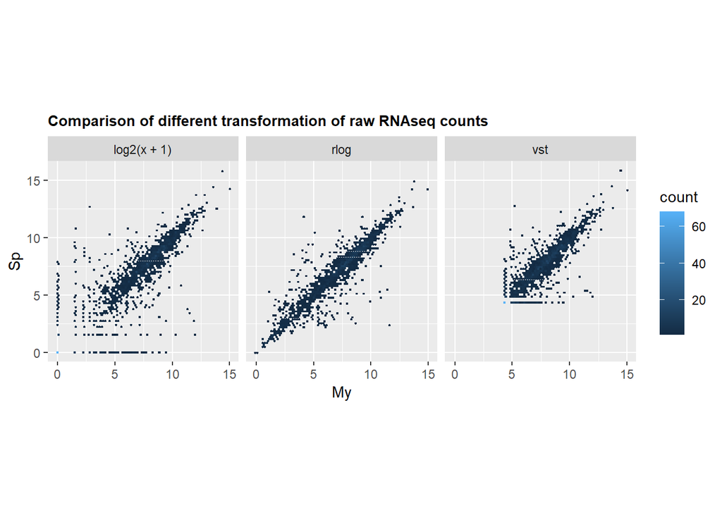

```r
ggplot(df.toPlot, aes(x = My, y = Sp)) + geom_hex(bins = 80) +
  coord_fixed() + facet_grid( . ~ transformation) +
  ggtitle("Comparison of different transformation of raw RNAseq counts") +
  theme(plot.title = element_text(size = 10, face = "bold"))
```

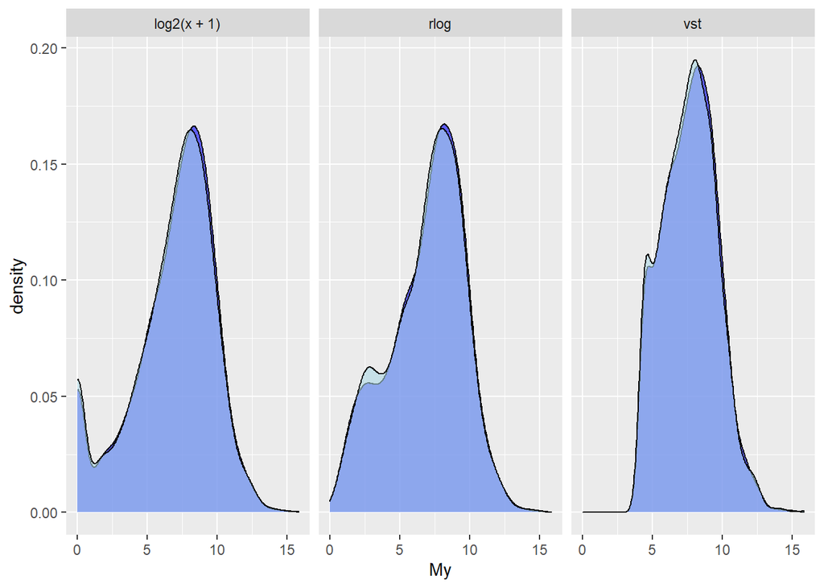

```r
ggplot(df.toPlot) +
  geom_density(aes(x = My), fill = "blue", alpha = 0.6) +
  geom_density(aes(x = Sp), fill = "light blue", alpha = 0.6) + facet_grid(~ transformation)
```

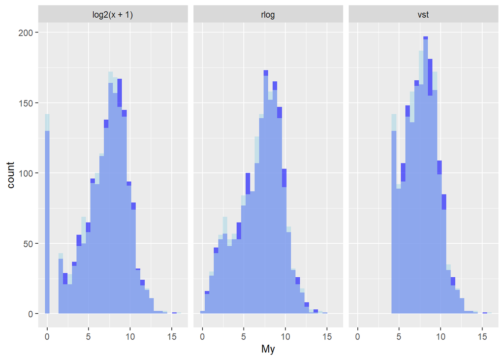

```r
ggplot(df.toPlot) +
  geom_histogram(aes(x = My), fill = "blue", alpha = 0.6) +
  geom_histogram(aes(x = Sp), fill = "light blue", alpha = 0.6) + facet_grid(~ transformation)
```

Result: The rlog transformation obviously looks better